# CH3_Methods for Generating Random Variables

# Chapter 1 Introduction

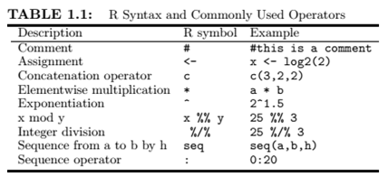

```r
knitr::include_graphics("table1_1.png")
```

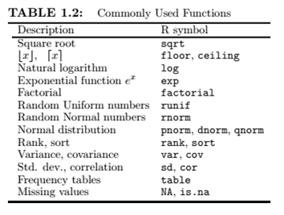

```r
knitr::include_graphics("table1_2.png")
```

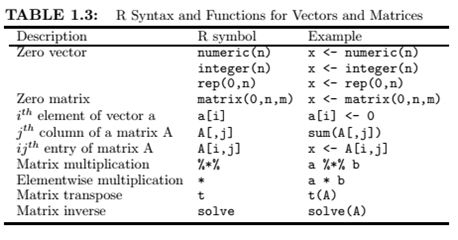

```r
knitr::include_graphics("table1_3.png")
```

# Chapter 3 Methods for Generating Random Variables

One of the fundamental tools required in computational statistics is the ability to simulate random variables from specified probability distributions. In this text we assume that a suitable uniform pseudo random number generator is available.

## 3.1 Introduction

### Example 3.1 (Sampling from a finite population)

```r
#toss some coins
sample(0:1, size = 10, replace = TRUE)
```

```
##  [1] 0 0 1 0 0 1 0 0 1 1
```

```r
#choose some lottery numbers
sample(1:100, size = 6, replace = FALSE)
```

```
## [1] 19 75 84 72 81  9
```

```r
#permuation of letters a-z
sample(letters)
```

```
##  [1] "p" "o" "e" "z" "y" "h" "a" "u" "m" "r" "s" "g" "n" "l" "f" "t" "k"
## [18] "b" "j" "d" "w" "q" "c" "x" "v" "i"
```

```r
#sample from a multinomial distribution
x <- sample(1:3, size = 100, replace = TRUE,
prob = c(.2, .3, .5))
table(x)
```

```
## x
##  1  2  3
## 21 37 42
```

### Random Generators of Common Probability Distributions in R

- dbinom(x, size, prob, log = FALSE)
- pbinom(q, size, prob, lower.tail = TRUE, log.p = FALSE)
- qbinom(p, size, prob, lower.tail = TRUE, log.p = FALSE)
- rbinom(n, size, prob) TABLE 3.1

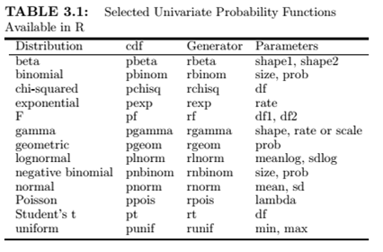

```r
knitr::include_graphics("table3_1.png")
```

## 3.2 The Inverse Transform Method

1. Derive the inverse function $F_X^{-1}(u)$.
2. Write a command or function to compute $F_X^{-1}(u)$.
3. For each random variate required:
1. Generate a random $u$ from Uniform(0,1).
2. Deliver $x=F_{X}^{-1}(u)$.

### 3.2.1 Inverse Transform Method, Continuous Case

### Example 3.2 (Inverse transform method, continuous case)

This example uses the inverse transform method to simulate a random sample from the distribution with density $f_X(x) = 3x^2,~ 0 < x < 1$.

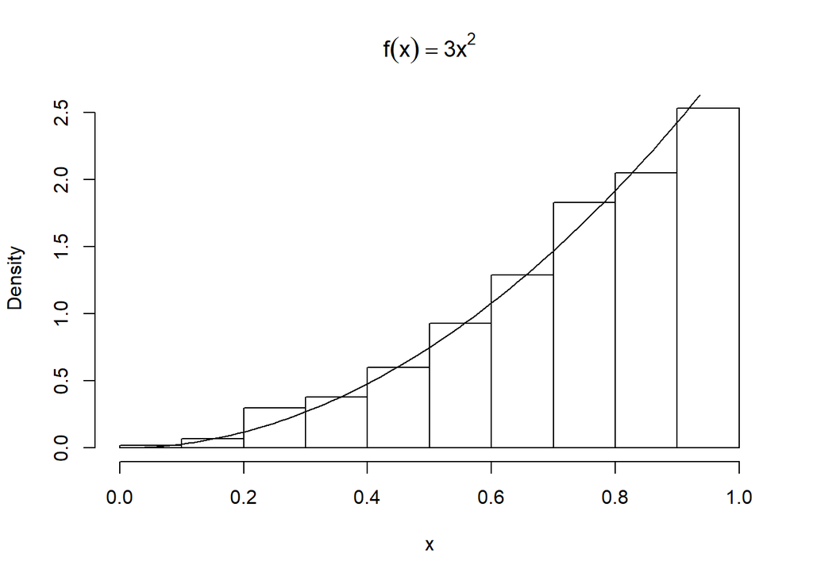

```r
    n <- 1000
    u <- runif(n)
    x <- u^(1/3)
    hist(x, prob = TRUE, main = bquote(f(x)==3*x^2)) #density histogram of sample
    y <- seq(0, 1, .01)
    lines(y, 3*y^2)    #density curve f(x)
```

FIGURE 3.1: Probability density histogram of a random sample generated by the inverse transform method in Example 3.2, with the theoretical density $f(x) = 3x^2$ superimposed.

### Example 3.3 (Exponential distribution)

Try it by yourself.

### Example 3.4 (Two point distribution)

This example applies the inverse transform to generate a random sample of Bernoulli($p = 0.4$) variates.

```r
    n <- 1000
    p <- 0.4
    u <- runif(n)
    x <- as.integer(u > 0.6)   #(u > 0.6) is a logical vector

    mean(x)
```

```
## [1] 0.387
```

```r
    var(x)
```

```
## [1] 0.2374685
```

### Example 3.5 (Geometric distribution)

Use the inverse transform method to generate a random geometric sample with parameter $p = 1/4$.

```r
    n <- 1000
    p <- 0.25
    u <- runif(n)
    k <- ceiling(log(1-u) / log(1-p)) - 1

    # more efficient
    k <- floor(log(u) / log(1-p))
```

### Example 3.6 (Logarithmic distribution) Try it by yourself.

```r
    rlogarithmic <- function(n, theta) {
        #returns a random logarithmic(theta) sample size n
        u <- runif(n)
        #set the initial length of cdf vector
        N <- ceiling(-16 / log10(theta))
        k <- 1:N
        a <- -1/log(1-theta)
        fk <- exp(log(a) + k * log(theta) - log(k))
        Fk <- cumsum(fk)
        x <- integer(n)
        for (i in 1:n) {
            x[i] <- as.integer(sum(u[i] > Fk)) #F^{-1}(u)-1
            while (x[i] == N) {
                #if x==N we need to extend the cdf
                #very unlikely because N is large
                logf <- log(a) + (N+1)*log(theta) - log(N+1)
                fk <- c(fk, exp(logf))
                Fk <- c(Fk, Fk[N] + fk[N+1])
                N <- N + 1
                x[i] <- as.integer(sum(u[i] > Fk))
            }
        }
        x + 1
    }

    n <- 1000
    theta <- 0.5
    x <- rlogarithmic(n, theta)
    #compute density of logarithmic(theta) for comparison
    k <- sort(unique(x))
    p <- -1 / log(1 - theta) * theta^k / k
    se <- sqrt(p*(1-p)/n)   #standard error

    round(rbind(table(x)/n, p, se),3)
```

```
##        1     2     3     4     5     6     7     8
##    0.724 0.186 0.053 0.016 0.014 0.005 0.001 0.001
## p  0.721 0.180 0.060 0.023 0.009 0.004 0.002 0.001
## se 0.014 0.012 0.008 0.005 0.003 0.002 0.001 0.001
```

## 3.3 The Acceptance-Rejection Method

Notes.

### Example 3.7 (Acceptance-rejection method)

This example illustrates the acceptance-rejection method for the beta distribution.

```r
    n <- 1000
    k <- 0      #counter for accepted
    j <- 0      #iterations
    y <- numeric(n)

    while (k < n) {
        u <- runif(1)
        j <- j + 1
        x <- runif(1)  #random variate from g
        if (x * (1-x) > u) {
            #we accept x
            k <- k + 1
            y[k] <- x
        }
    }

    j
```

```
## [1] 6110
```

```r
    #compare empirical and theoretical percentiles
    p <- seq(.1, .9, .1)
    Qhat <- quantile(y, p)   #quantiles of sample
    Q <- qbeta(p, 2, 2)      #theoretical quantiles
    se <- sqrt(p * (1-p) / (n * dbeta(Q, 2, 2)^2)) #see Ch. 2
    round(rbind(Qhat, Q, se), 3)
```

```
##        10%   20%   30%   40%   50%   60%   70%   80%   90%
## Qhat 0.182 0.271 0.364 0.439 0.513 0.573 0.646 0.717 0.813
## Q    0.196 0.287 0.363 0.433 0.500 0.567 0.637 0.713 0.804
## se   0.010 0.010 0.010 0.011 0.011 0.011 0.010 0.010 0.010
```

## 3.4 Transformation Methods

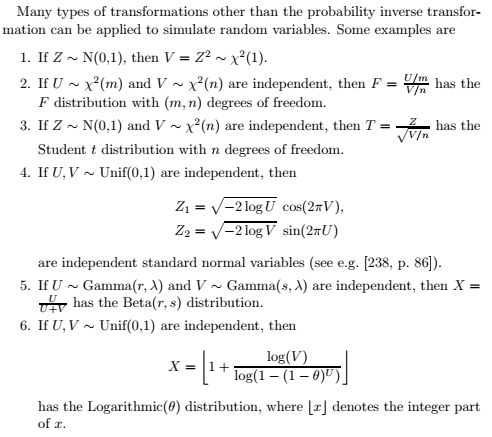

```r
knitr::include_graphics("section3_4.png")
```

### Example 3.8 (Beta distribution)

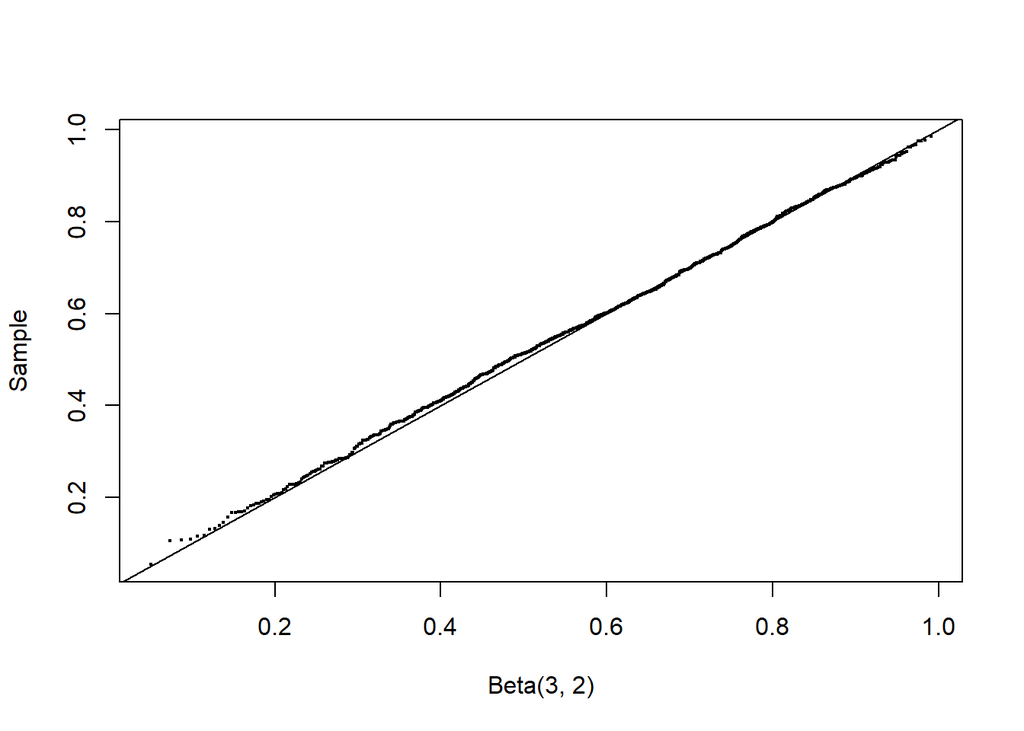

```r
    n <- 1000
    a <- 3
    b <- 2
    u <- rgamma(n, shape=a, rate=1)
    v <- rgamma(n, shape=b, rate=1)
    x <- u / (u + v)

    q <- qbeta(ppoints(n), a, b)
    qqplot(q, x, cex=0.25, xlab="Beta(3, 2)", ylab="Sample")
    abline(0, 1)
```

FIGURE 3.2: QQ Plot comparing the Beta(3, 2) distribution with a simulated random sample generated by the ratio of gammas method in Example 3.8.

### Example 3.9 (Logarithmic distribution, version 2) Try it by yourself!

```r
    n <- 1000
    theta <- 0.5
    u <- runif(n)  #generate logarithmic sample
    v <- runif(n)
    x <- floor(1 + log(v) / log(1 - (1 - theta)^u))
    k <- 1:max(x)  #calc. logarithmic probs.
    p <- -1 / log(1 - theta) * theta^k / k
    se <- sqrt(p*(1-p)/n)
    p.hat <- tabulate(x)/n

    print(round(rbind(p.hat, p, se), 3))
```

```
##        [,1]  [,2]  [,3]  [,4]  [,5]  [,6]  [,7]  [,8]  [,9]
## p.hat 0.723 0.169 0.061 0.029 0.008 0.004 0.003 0.001 0.002
## p     0.721 0.180 0.060 0.023 0.009 0.004 0.002 0.001 0.000
## se    0.014 0.012 0.008 0.005 0.003 0.002 0.001 0.001 0.001
```

```r
    # The following function is a simple replacement for
    # rlogarithmic in Example 3.6

    rlogarithmic <- function(n, theta) {
        stopifnot(all(theta > 0 & theta < 1))
        th <- rep(theta, length=n)
        u <- runif(n)
        v <- runif(n)
        x <- floor(1 + log(v) / log(1 - (1 - th)^u))
        return(x)
    }
```

## 3.5 Sums and Mixtures

Sums and mixtures of random variables are special types of transformations. In this section we focus on sums of independent random variables (convolutions) and several examples of discrete and continuous mixtures.

### Example 3.10 (Chisquare)

```r
    n <- 1000
    nu <- 2
    X <- matrix(rnorm(n*nu), n, nu)^2 #matrix of sq. normals
    #sum the squared normals across each row: method 1
    y <- rowSums(X)
    #method 2
    y <- apply(X, MARGIN=1, FUN=sum)  #a vector length n
    mean(y)
```

```
## [1] 1.88727
```

```r
    mean(y^2)
```

```
## [1] 7.175485
```

### Example 3.11 (Convolutions and mixtures)

Let $X_1$ ∼ Gamma(2, 2) and $X_2$ ∼ Gamma(2, 4) be independent. Compare the histograms of the samples generated by the convolution $S = X_1 +X_2$ and the mixture $F_X = 0.5F_{X_1} + 0.5 F_{X_2}$.

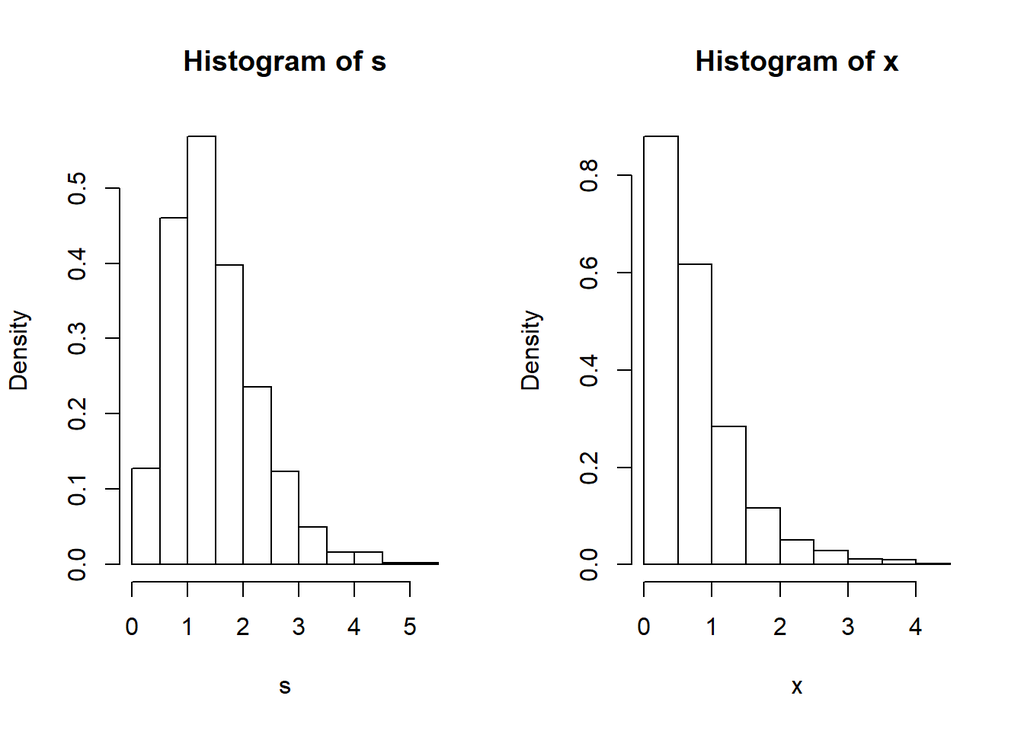

```r
    n <- 1000
    x1 <- rgamma(n, 2, 2)
    x2 <- rgamma(n, 2, 4)
    s <- x1 + x2              #the convolution
    u <- runif(n)
    k <- as.integer(u > 0.5)  #vector of 0's and 1's
    x <- k * x1 + (1-k) * x2  #the mixture

    par(mfcol=c(1,2))         #two graphs per page
    hist(s, prob=TRUE)
    hist(x, prob=TRUE)
```

```r
    par(mfcol=c(1,1))         #restore display
```

FIGURE 3.3: Histogram of a simulated convolution of Gamma(2, 2) and Gamma(2, 4) random variables (left), and a 50% mixture of the same variables (right), from Example 3.11.

### Example 3.12 (Mixture of several gamma distributions)

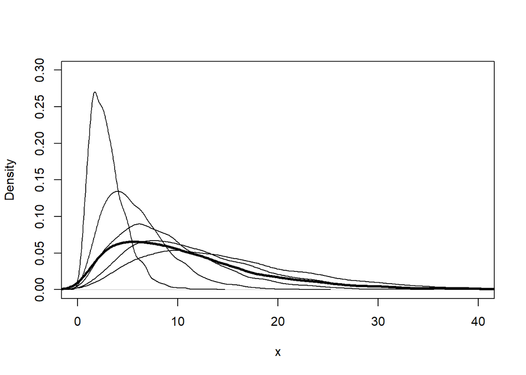

```r
    n <- 5000
    k <- sample(1:5, size=n, replace=TRUE, prob=(1:5)/15)
    rate <- 1/k
    x <- rgamma(n, shape=3, rate=rate)

    #plot the density of the mixture
    #with the densities of the components
    plot(density(x), xlim=c(0,40), ylim=c(0,.3),
        lwd=3, xlab="x", main="")
    for (i in 1:5)
        lines(density(rgamma(n, 3, 1/i)))
```

FIGURE 3.4: Density estimates from Example 3.12: A mixture (thick line) of several gamma densities (thin lines).

## 3.6 Multivariate Distributions

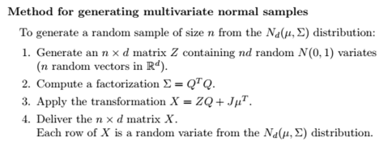

```r
knitr::include_graphics("section3_6.png")
```

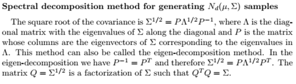

```r
knitr::include_graphics("section3_6_2.png")
```

### Example 3.16 (Spectral decomposition method)

```r
    # mean and covariance parameters
    mu <- c(0, 0)
    Sigma <- matrix(c(1, .9, .9, 1), nrow = 2, ncol = 2)

    rmvn.eigen <-
    function(n, mu, Sigma) {
        # generate n random vectors from MVN(mu, Sigma)
        # dimension is inferred from mu and Sigma
        d <- length(mu)
        ev <- eigen(Sigma, symmetric = TRUE)
        lambda <- ev$values
        V <- ev$vectors
        R <- V %*% diag(sqrt(lambda)) %*% t(V)
        Z <- matrix(rnorm(n*d), nrow = n, ncol = d)
        X <- Z %*% R + matrix(mu, n, d, byrow = TRUE)
        X
    }

    # generate the sample
    X <- rmvn.eigen(1000, mu, Sigma)

    print(colMeans(X))
```

```
## [1] 0.015322848 0.007599976
```

```r
    print(cor(X))
```

```
##           [,1]      [,2]
## [1,] 1.0000000 0.8977231
## [2,] 0.8977231 1.0000000
```

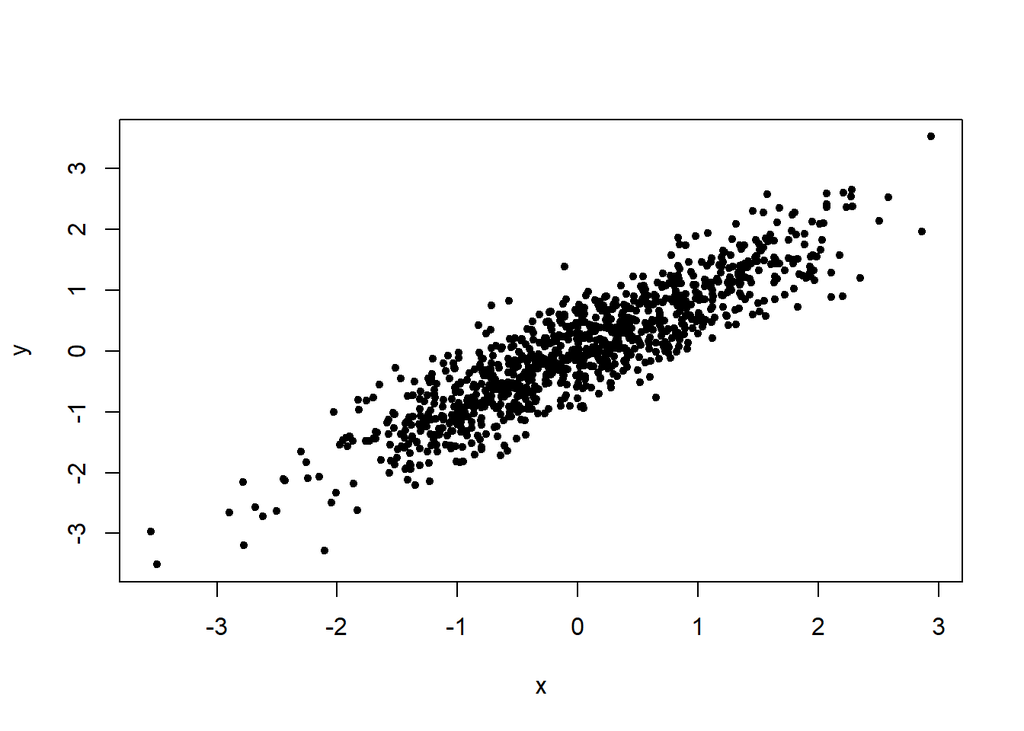

```r
    plot(X, xlab = "x", ylab = "y", pch = 20)
```

FIGURE 3.6: Scatterplot of a random bivariate normal sample with mean vector zero, variances σ12 = σ22 = 1 and correlation ρ = 0.9, from Example 3.16.

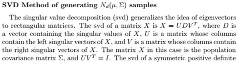

```r
knitr::include_graphics("section3_6_31.png")
```

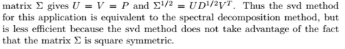

```r
knitr::include_graphics("section3_6_32.png")
```

### Example 3.17 (SVD method)

```r
    rmvn.svd <-
    function(n, mu, Sigma) {
        # generate n random vectors from MVN(mu, Sigma)
        # dimension is inferred from mu and Sigma
        d <- length(mu)
        S <- svd(Sigma)
        R <- S$u %*% diag(sqrt(S$d)) %*% t(S$v) #sq. root Sigma
        Z <- matrix(rnorm(n*d), nrow=n, ncol=d)
        X <- Z %*% R + matrix(mu, n, d, byrow=TRUE)
        X
    }
```

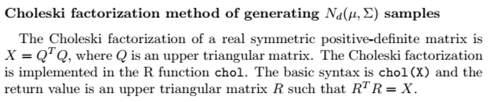

```r
knitr::include_graphics("section3_6_4.png")
```

### Example 3.18 (Choleski factorization method)

```r
    rmvn.Choleski <-
    function(n, mu, Sigma) {
        # generate n random vectors from MVN(mu, Sigma)
        # dimension is inferred from mu and Sigma
        d <- length(mu)
        Q <- chol(Sigma) # Choleski factorization of Sigma
        Z <- matrix(rnorm(n*d), nrow=n, ncol=d)
        X <- Z %*% Q + matrix(mu, n, d, byrow=TRUE)
        X
    }
```

```r
    #generating the samples according to the mean and covariance
    #structure as the four-dimensional iris virginica data
    y <- subset(x=iris, Species=="virginica")[, 1:4]
    mu <- colMeans(y)
    Sigma <- cov(y)
    mu
```

```
## Sepal.Length  Sepal.Width Petal.Length  Petal.Width
##        6.588        2.974        5.552        2.026
```

```r
    Sigma
```

```
##              Sepal.Length Sepal.Width Petal.Length Petal.Width
## Sepal.Length   0.40434286  0.09376327   0.30328980  0.04909388
## Sepal.Width    0.09376327  0.10400408   0.07137959  0.04762857
## Petal.Length   0.30328980  0.07137959   0.30458776  0.04882449
## Petal.Width    0.04909388  0.04762857   0.04882449  0.07543265
```

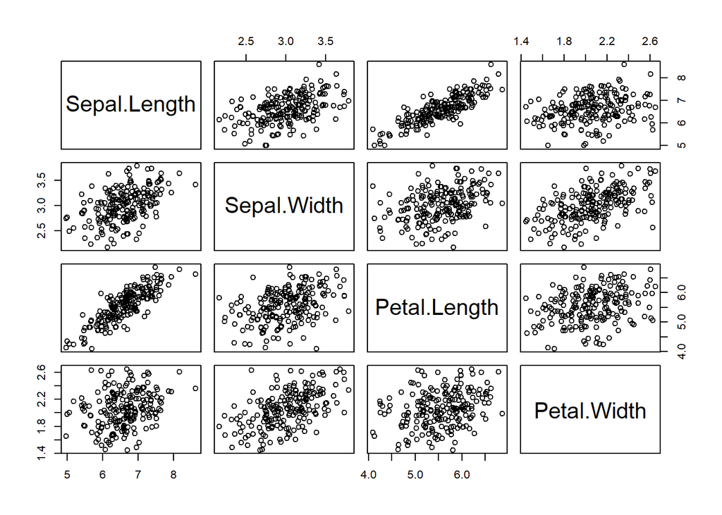

```r
    #now generate MVN data with this mean and covariance
    X <- rmvn.Choleski(200, mu, Sigma)
    pairs(X)
```

FIGURE 3.7: Pairs plot of the bivariate marginal distributions of a simulated multivariate normal random sample in Example 3.18. The parameters match the mean and covariance of the iris virginica data.

## 3.7 Stochastic Processes

A stochastic process is a collection $\{X(t) : t ∈ T\}$ of random variables indexed by the set $T$, which usually represents time. The index set $T$ could be discrete or continuous.

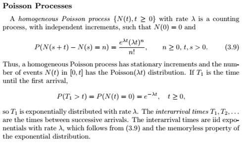

```r
knitr::include_graphics("section3_7.png")
```

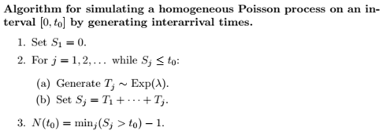

```r
knitr::include_graphics("section3_7_2.png")
```

### Example 3.22 (Poisson process)

```r
    lambda <- 2
    t0 <- 3
    Tn <- rexp(100, lambda)       #interarrival times
    Sn <- cumsum(Tn)              #arrival times
    n <- min(which(Sn > t0))      #arrivals+1 in [0, t0]
    n-1
```

```
## [1] 3
```

```r
    round(Sn[1:n], 4)
```

```
## [1] 0.0560 0.1583 2.7715 4.1312
```

### Example 3.23 (Poisson process, cont.)

Returning to Example 3.22, simulate a Poisson($\lambda$) process and find $N(3)$, using the conditional distribution of the arrival times. As a check, we estimate the mean and variance of $N(3)$ from 10000 replications.

```r
    lambda <- 2
    t0 <- 3
    upper <- 100
    pp <- numeric(10000)
    for (i in 1:10000) {
        N <- rpois(1, lambda * upper)
        Un <- runif(N, 0, upper)      #unordered arrival times
        Sn <- sort(Un)                #arrival times
        n <- min(which(Sn > t0))      #arrivals+1 in [0, t0]
        pp[i] <- n - 1                #arrivals in [0, t0]
        }

    #alternately, the loop can be replaced by replicate function
    pp <- replicate(10000, expr = {
        N <- rpois(1, lambda * upper)
        Un <- runif(N, 0, upper)      #unordered arrival times
        Sn <- sort(Un)                #arrival times
        n <- min(which(Sn > t0))      #arrivals+1 in [0, t0]
        n - 1  })                     #arrivals in [0, t0]

    c(mean(pp), var(pp))
```

```
## [1] 6.010300 5.939588
```

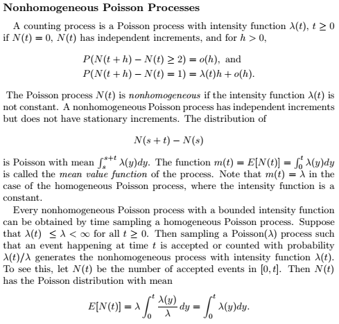

```r
knitr::include_graphics("section3_7_3.png")
```

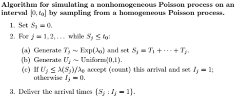

```r
knitr::include_graphics("section3_7_4.png")
```

### Example 3.24 (Nonhomogeneous Poisson process)

```r
    lambda <- 3
    upper <- 100
    N <- rpois(1, lambda * upper)
    Tn <- rexp(N, lambda)
    Sn <- cumsum(Tn)
    Un <- runif(N)
    keep <- (Un <= cos(Sn)^2)    #indicator, as logical vector
    Sn[keep]
```

```
##   [1]   0.3536971   0.5109649   2.2785177   2.6385196   2.8545633
##   [6]   3.2720699   3.8347645   5.8546303   6.5357582   9.1521039
##  [11]   9.1676032   9.4936495  10.4369114  12.0638713  12.5627913
##  [16]  12.5733381  12.6097362  12.9110336  13.1770471  14.8092628
##  [21]  15.3770534  16.0166557  18.0739798  18.1001072  18.1797920
##  [26]  18.3545890  18.7286693  18.9368010  19.1035081  19.5521714
##  [31]  19.6154367  21.2748111  21.6862718  21.8404539  22.2235541
##  [36]  22.4786557  22.4930777  25.1752369  25.2922495  25.5327728
##  [41]  28.0696407  28.3159737  28.3188020  28.3303895  28.4523326
##  [46]  28.7043856  30.4114574  30.5893895  30.6480460  30.6542426
##  [51]  30.9720062  31.0670133  31.2487008  31.6802531  31.8835960
##  [56]  32.1289734  33.7916521  34.2246301  34.4296557  34.7729912
##  [61]  35.5683283  37.7980555  37.8122506  38.0406872  38.1972637
##  [66]  39.9202708  40.7637501  40.8338283  40.9525848  41.0123543
##  [71]  41.7871152  41.8701865  41.9195811  43.3899710  44.0152645
```

[output cut: 18 more lines]

```r
    round(Sn[keep], 4)
```

```
##   [1]   0.3537   0.5110   2.2785   2.6385   2.8546   3.2721   3.8348
##   [8]   5.8546   6.5358   9.1521   9.1676   9.4936  10.4369  12.0639
##  [15]  12.5628  12.5733  12.6097  12.9110  13.1770  14.8093  15.3771
##  [22]  16.0167  18.0740  18.1001  18.1798  18.3546  18.7287  18.9368
##  [29]  19.1035  19.5522  19.6154  21.2748  21.6863  21.8405  22.2236
##  [36]  22.4787  22.4931  25.1752  25.2922  25.5328  28.0696  28.3160
##  [43]  28.3188  28.3304  28.4523  28.7044  30.4115  30.5894  30.6480
##  [50]  30.6542  30.9720  31.0670  31.2487  31.6803  31.8836  32.1290
##  [57]  33.7917  34.2246  34.4297  34.7730  35.5683  37.7981  37.8123
##  [64]  38.0407  38.1973  39.9203  40.7638  40.8338  40.9526  41.0124
##  [71]  41.7871  41.8702  41.9196  43.3900  44.0153  44.3106  44.5255
##  [78]  46.2778  46.5545  47.0136  47.1477  47.1846  47.3504  47.5359
##  [85]  50.1187  50.5167  50.9309  51.5460  53.6843  53.9670  54.0752
##  [92]  54.5559  55.4023  55.9892  56.6796  57.3926  59.0432  60.2571
##  [99]  60.8991  62.3660  62.6292  62.8173  63.3435  63.6896  66.4424
## [106]  67.0310  68.8784  68.9067  69.3865  72.8372  72.9131  73.0019
## [113]  73.0030  73.1580  74.6948  75.6732  78.1090  78.4387  78.5466
## [120]  81.1963  81.7118  84.3184  85.1325  87.2989  87.5007  87.7741
## [127]  87.8313  88.3257  88.4560  91.3788  91.3988  93.5171  94.0023
## [134]  94.3775  94.4142  94.4460  97.1099 100.0577 100.7297 100.7758
## [141] 100.8658 101.3916 103.5558 104.3966 105.6064 106.8050 109.4223
## [148] 109.6481 110.3242 110.5707 112.5764 112.7586 113.1305 113.1384
## [155] 113.2850 113.9084 114.0193 116.2492 116.2585 116.2895 116.7310
## [162] 117.2842
```

```r
  sum(Sn[keep] <= 2*pi)
```

```
## [1] 8
```

```r
  table(keep)/N
```

```
## keep
##     FALSE      TRUE
## 0.5178571 0.4821429
```

### Renewal Process

A renewal process is a generalization of the Poisson process.

### Example 3.25 (Renewal process)

Suppose the interarrival times of a renewal process have the geometric distribution with success probability p. (This example is discussed in [234, Sec. 7.2].) Then the interarrival times are nonnegative integers, and $S_j = T_1 + · · · + T_j$ have the negative binomial distribution with size parameter $r = j$ and probability $p$. The process can be simulated by generating geometric interarrival times and computing the consecutive arrival times by the cumulative sum of interarrival times.

```r
    t0 <- 5
    Tn <- rgeom(100, prob = .2)   #interarrival times
    Sn <- cumsum(Tn)              #arrival times
    n <- min(which(Sn > t0))      #arrivals+1 in [0, t0]

    Nt0 <- replicate(1000, expr = {
        Sn <- cumsum(rgeom(100, prob = .2))
        min(which(Sn > t0)) - 1
        })
    table(Nt0)/1000
```

```
## Nt0
##     0     1     2     3     4     5     6     7     8
## 0.273 0.319 0.211 0.121 0.052 0.016 0.006 0.001 0.001
```

```r
    Nt0
```

[output not shown]

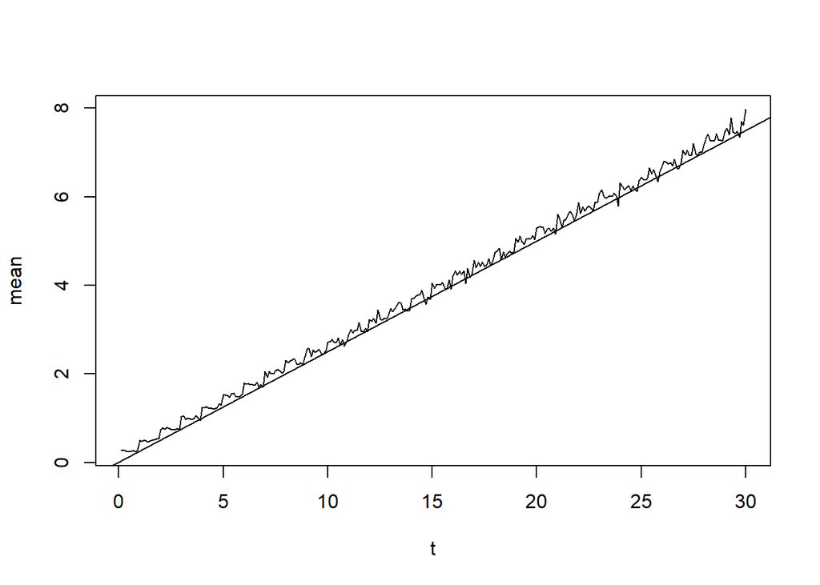

```r
    t0 <- seq(0.1, 30, .1)
    mt <- numeric(length(t0))

    for (i in 1:length(t0)) {
        mt[i] <- mean(replicate(1000,
        {
        Sn <- cumsum(rgeom(100, prob = .2))
        min(which(Sn > t0[i])) - 1
        }))
    }
    plot(t0, mt, type = "l", xlab = "t", ylab = "mean")
    abline(0, .25)
```

FIGURE 3.10: Sequence of sample means of a simulated renewal process in Example 3.25. The reference line corresponds to the mean $\lambda t = t/4$ of a homogeneous Poisson process.

### Example 3.26 (Symmetric random walk)

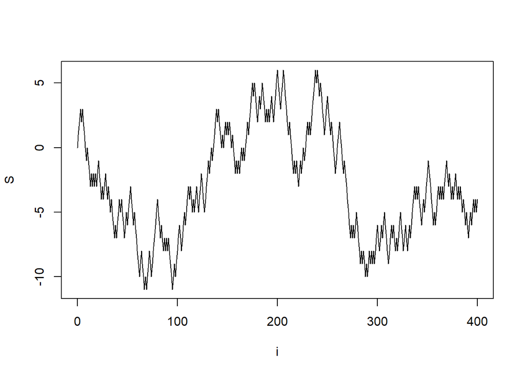

```r
    n <- 400
    incr <- sample(c(-1, 1), size = n, replace = TRUE)
    S <- as.integer(c(0, cumsum(incr)))
    plot(0:n, S, type = "l", main = "", xlab = "i")
```

FIGURE 3.11: Partial realization of a symmetric random walk in Example 3.26.

```r
  which(S==0)
```

```
##  [1]   1   9  11 135 137 145 147 155 157 165 167 169 215 227 229 257 261
## [18] 265
```

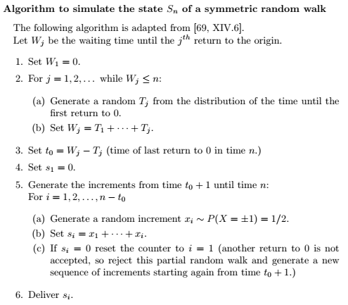

```r
knitr::include_graphics("section3_8.png")
```

### Example 3.27 (Generator for the time until return to origin) Optional!

```r
    set.seed(12345)

    #compute the probabilities directly
    n <- 1:10000
    p2n <- exp(lgamma(2*n-1)
              - log(n) - (2*n-1)*log(2) - 2*lgamma(n))
    #or compute using dbinom
    P2n <- (.5/n) * dbinom(n-1, size = 2*n-2, prob = 0.5)
    pP2n <- cumsum(P2n)

    #given n compute the time of the last return to 0 in (0,n]
    n <- 200
    sumT <- 0
    while (sumT <= n) {
        u <- runif(1)
        s <- sum(u > pP2n)
        if (s == length(pP2n))
            warning("T is truncated")
        Tj <- 2 * (1 + s)
        #print(c(Tj, sumT))
        sumT <- sumT + Tj
        }
    sumT - Tj
```

```
## [1] 132
```